# Lab Session 2 - 1.5 Hours

# Convolutional Neural Network (CNN) for Handwritten Digits Recognition

**Group name:** deeplearn25

The aim of this session is to practice with Convolutional Neural Networks. Each group should fill and run appropriate notebook cells.

Generate your final report (export as HTML) and upload it on the submission website http://bigfoot-m1.eurecom.fr/teachingsub/login (using your deeplearnXX/password). Do not forget to run all your cells before generating your final report and do not forget to include the names of all participants in the group. The lab session should be completed and submitted by May 30th 2018 (23:59:59 CET).

# Introduction

In the previous Lab Session, you built a Multilayer Perceptron for recognizing hand-written digits from the MNIST data-set. The best achieved accuracy on testing data was about 97%. Can you do better than these results using a deep CNN ? In this Lab Session, you will build, train and optimize in TensorFlow one of the early Convolutional Neural Networks, **LeNet-5**, to go to more than 99% of accuracy.

```python
import warnings
warnings.simplefilter("ignore")
```

# Load MNIST Data in TensorFlow

Run the cell below to load the MNIST data that comes with TensorFlow. You will use this data in **Section 1** and **Section 2**.

```python
import tensorflow as tf
import numpy as np
from tensorflow.examples.tutorials.mnist import input_data
mnist = input_data.read_data_sets("MNIST_data/", one_hot=True)
X_train, y_train           = mnist.train.images, mnist.train.labels
X_validation, y_validation = mnist.validation.images, mnist.validation.labels
X_test, y_test             = mnist.test.images, mnist.test.labels
print("Image Shape: {}".format(X_train[0].shape))
print("Training Set:   {} samples".format(len(X_train)))
print("Validation Set: {} samples".format(len(X_validation)))
print("Test Set:       {} samples".format(len(X_test)))

epsilon = 1e-10 # this is a parameter you will use later
```

```
Extracting MNIST_data/train-images-idx3-ubyte.gz
Extracting MNIST_data/train-labels-idx1-ubyte.gz
Extracting MNIST_data/t10k-images-idx3-ubyte.gz
Extracting MNIST_data/t10k-labels-idx1-ubyte.gz
Image Shape: (784,)
Training Set:   55000 samples
Validation Set: 5000 samples
Test Set:       10000 samples
```

# Section 1 : My First Model in TensorFlow

Before starting with CNN, let's train and test in TensorFlow the example **y=softmax(Wx+b)** seen in the first lab.

This model reaches an accuracy of about 92 %. You will also learn how to launch the TensorBoard https://www.tensorflow.org/get_started/summaries_and_tensorboard to visualize the computation graph, statistics and learning curves.

**Part 1** : Read carefully the code in the cell below. Run it to perform training.

```python
#STEP 1

# Parameters
learning_rate = 0.01
training_epochs = 40
batch_size = 128
display_step = 10
logs_path = 'log_files/'  # useful for tensorboard

# tf Graph Input:  mnist data image of shape 28*28=784
x = tf.placeholder(tf.float32, [None, 784], name='InputData')
# 0-9 digits recognition,  10 classes
y = tf.placeholder(tf.float32, [None, 10], name='LabelData')

# Set model weights
W = tf.Variable(tf.zeros([784, 10]), name='Weights')
b = tf.Variable(tf.zeros([10]), name='Bias')

# Construct model and encapsulating all ops into scopes, making Tensorboard's Graph visualization more convenient
with tf.name_scope('Model'):
    # Model
    pred = tf.nn.softmax(tf.matmul(x, W) + b) # Softmax
with tf.name_scope('Loss'):
    # Minimize error using cross entropy
    # We use tf.clip_by_value to avoid having too low numbers in the log function
    cost = tf.reduce_mean(-tf.reduce_sum(y*tf.log(tf.clip_by_value(pred, epsilon, 1.0)), reduction_indices=1))
with tf.name_scope('SGD'):
    # Gradient Descent
    optimizer = tf.train.GradientDescentOptimizer(learning_rate).minimize(cost)
with tf.name_scope('Accuracy'):
    # Accuracy
    acc = tf.equal(tf.argmax(pred, 1), tf.argmax(y, 1))
    acc = tf.reduce_mean(tf.cast(acc, tf.float32))

# Initializing the variables
init = tf.global_variables_initializer()
# Create a summary to monitor cost tensor
tf.summary.scalar("Loss", cost)
# Create a summary to monitor accuracy tensor
tf.summary.scalar("Accuracy", acc)
# Merge all summaries into a single op
merged_summary_op = tf.summary.merge_all()

#STEP 2

# Launch the graph for training
with tf.Session() as sess:
    sess.run(init)
    # op to write logs to Tensorboard
    summary_writer = tf.summary.FileWriter(logs_path, graph=tf.get_default_graph())
    # Training cycle
    for epoch in range(training_epochs):
        avg_cost = 0.
        total_batch = int(mnist.train.num_examples/batch_size)
        # Loop over all batches
        for i in range(total_batch):
            batch_xs, batch_ys = mnist.train.next_batch(batch_size, shuffle=(i==0))
            # Run optimization op (backprop), cost op (to get loss value)
            # and summary nodes
            _, c, summary = sess.run([optimizer, cost, merged_summary_op],
                                     feed_dict={x: batch_xs, y: batch_ys})
            # Write logs at every iteration
            summary_writer.add_summary(summary, epoch * total_batch + i)
            # Compute average loss
            avg_cost += c / total_batch
        # Display logs per epoch step
        if (epoch+1) % display_step == 0:
            print("Epoch: ", '%02d' % (epoch+1), "  =====> Loss=", "{:.9f}".format(avg_cost))

    print("Optimization Finished!")
    summary_writer.flush()

    # Test model
    # Calculate accuracy
    print("Accuracy:", acc.eval({x: mnist.test.images, y: mnist.test.labels}))
```

```
Epoch:  10   =====> Loss= 0.413110808
Epoch:  20   =====> Loss= 0.359653309
Epoch:  30   =====> Loss= 0.336854825
Epoch:  40   =====> Loss= 0.323114058
Optimization Finished!
Accuracy: 0.9162
```

**Part 2** : Using Tensorboard, we can now visualize the created graph, giving you an overview of your architecture and how all of the major components are connected. You can also see and analyse the learning curves.

To launch tensorBoard:

- Open a Terminal and run the command line **"tensorboard --logdir=lab_2/log_files/"**
- Click on "Tensorboard web interface" in Zoe

Enjoy It !!

# Section 2 : The 99% MNIST Challenge !

**Part 1** : LeNet5 implementation

You are now more familar with **TensorFlow** and **TensorBoard**. In this section, you are to build, train and test the baseline [LeNet-5](http://yann.lecun.com/exdb/lenet/) model for the MNIST digits recognition problem.

Then, you will make some optimizations to get more than 99% of accuracy.

For more informations, have a look at this list of results: http://rodrigob.github.io/are_we_there_yet/build/classification_datasets_results.html

Figure 1: Lenet-5

The LeNet architecture takes a 28x28xC image as input, where C is the number of color channels. Since MNIST images are grayscale, C is 1 in this case.

**Layer 1 - Convolution (5x5):** The output shape should be 28x28x6. **Activation:** ReLU. **MaxPooling:** The output shape should be 14x14x6.

**Layer 2 - Convolution (5x5):** The output shape should be 10x10x16. **Activation:** ReLU. **MaxPooling:** The output shape should be 5x5x16.

**Flatten:** Flatten the output shape of the final pooling layer such that it's 1D instead of 3D. You may need to use tf.reshape.

**Layer 3 - Fully Connected:** This should have 120 outputs. **Activation:** ReLU.

**Layer 4 - Fully Connected:** This should have 84 outputs. **Activation:** ReLU.

**Layer 5 - Fully Connected:** This should have 10 outputs. **Activation:** softmax.

**Question 2.1.1** Implement the Neural Network architecture described above. For that, your will use classes and functions from https://www.tensorflow.org/api_docs/python/tf/nn.

We give you some helper functions for weigths and bias initilization. Also you can refer to section 1.

```python
# Functions for weigths and bias initilization
def weight_variable(shape):
    initial = tf.truncated_normal(shape, stddev=0.1)
    return tf.Variable(initial)

def bias_variable(shape):
    initial = tf.constant(0., shape=shape)
    return tf.Variable(initial)
```

```python
#Implement 2d convolution for our architecture
def conv2d(input_layer, W, b, padding, activation, pooling, name):
    conv = tf.nn.conv2d(
        input_layer, W, strides=[1, 1, 1, 1], padding=padding, name=name
    )
    return pooling(activation(conv + b))

#Implement full connection qs defined in the lesson
def fully_connected(input_layer, n_input, n_output, activation, name):
    W, b = weight_variable((n_input, n_output)), bias_variable((n_output,))
    return activation(input_layer @ W + b)
```

```python
from functools import partial
def LeNet5_Model(image, dropout=False):
    #reshape the input
    layer0 = tf.reshape(image, (-1, 28, 28, 1))

    # Layer 1 :
    layer1 = conv2d(
        input_layer = layer0,
        W = weight_variable((5, 5, 1, 6)),
        b = bias_variable((6,)),
        padding = "SAME",
        activation = tf.nn.sigmoid,
        pooling = partial(tf.nn.max_pool,
                          ksize=[1, 2, 2, 1],
                          strides=[1, 2, 2, 1],
                          padding='VALID'),
        name="Layer1"
    )

    # Layer 2 :
    layer2 = conv2d(
        input_layer = layer1,
        W = weight_variable((5, 5, 6, 16)),
        b = bias_variable((16,)),
        padding = "VALID",
        activation = tf.nn.sigmoid,
        pooling = partial(tf.nn.max_pool,
                          ksize=[1, 2, 2, 1],
                          strides=[1, 2, 2, 1],
                          padding='VALID'),
        name="Layer2"
    )

    layer3 = fully_connected(
        tf.contrib.layers.flatten(
            # Perform the dropout if needed
            tf.nn.dropout(layer2, keep_prob = 0.75)
            if dropout
            else layer2
        ),
        n_input=400,
        n_output=120,
        activation=tf.nn.relu,
        name="Layer3"
    )

    layer4 = fully_connected(
        layer3,
        n_input=120,
        n_output=84,
        activation=tf.nn.relu,
        name="Layer4"
    )

    layer5 = fully_connected(
        layer4,
        n_input=84,
        n_output=10,
        activation=tf.nn.softmax,
        name="Layer5"
    )
    return layer5
```

**Question 2.1.2.** Calculate the number of parameters of this model

##### The parameters are the weights of the connexions between layers in the neural network (either the filter matrices for convolutions and the weights for the fully connected layers).

- For the convolution layers : product of the shape + bias size
- For the fully connected layers : product of the size of the input an of the output + bias (= size of the output)

Therefore we can state the following:

- Layer 1: $5\times5\times1\times6 + 6$
  - = 156 parameters
- Layer 2: $5\times5\times6\times16 + 16$
  - = 2416 parameters
- Layer 3: $400 \times 120 + 120$
  - = 48120 parameters
- Layer 4: $120 \times 84 + 84$
  - = 10164 parameters
- Layer 5: $84 \times 10 + 10$
  - = 850 parameters
- Total: 61706 parameters

**Question 2.1.3.** Define your model, its accuracy and the loss function according to the following parameters (you can look at Section 1 to see what is expected):

```
 Learning rate: 0.001
 Loss Function: Cross-entropy
 Optimizer: tf.train.GradientDescentOptimizer
 Number of epochs: 40
 Batch size: 128
```

```python
tf.reset_default_graph() # reset the default graph before defining a new model

# Parameters
learning_rate = .01
training_epochs = 40
batch_size = 128
logs_path = 'log_files/'

# Model
x = tf.placeholder(tf.float32, shape=(None, 784), name='InputData')
y = tf.placeholder(tf.float32, shape=(None, 10), name='LabelData')

modelSGD = LeNet5_Model(x)

with tf.name_scope('Loss_SGD'):
    costSGD = tf.reduce_mean(-tf.reduce_sum(
        y*tf.log(tf.clip_by_value(modelSGD, epsilon, 1.0)),
        reduction_indices=1
    ))
with tf.name_scope('Optimisation_SGD'):
    optimizerSGD = tf.train.GradientDescentOptimizer(learning_rate).minimize(costSGD)
```

**Question 2.1.4.** Implement the evaluation function for accuracy computation

```python
def evaluate(logits, labels):
    """
        This function returns the accuracy of your model
    """
    return tf.reduce_mean(tf.cast(
        tf.equal(tf.argmax(logits, 1), tf.argmax(labels, 1)),
        tf.float32
    ))

with tf.name_scope('Accuracy_SGD'):
    accuracySGD = evaluate(modelSGD, y)
```

**Question 2.1.5.** Implement training pipeline and run the training data through it to train the model.

- Before each epoch, shuffle the training set.
- Print the loss per mini batch and the training/validation accuracy per epoch. (Display results every 10 epochs)
- Save the model after training
- Print after training the final testing accuracy

```python
# Initializing the variables
init = tf.global_variables_initializer()
# Create a summary to monitor cost tensor
tf.summary.scalar("Loss_LeNet-5_SGD", costSGD)
# Create a summary to monitor accuracy tensor
tf.summary.scalar("Accuracy_LeNet-5_SGD", accuracySGD)
# Merge all summaries into a single op
merged_summary_op = tf.summary.merge_all()

def train(init, sess, logs_path, n_epochs, batch_size, optimizer, cost, accuracy, merged_summary_op):
    sess.run(init)
    summary_writer = tf.summary.FileWriter(logs_path, graph=tf.get_default_graph())
    for epoch in range(training_epochs):
        total_batch = int(mnist.train.num_examples/batch_size)
        for i in range(mnist.train.num_examples // batch_size):
            x_set, y_set = mnist.train.next_batch(batch_size, shuffle=i==0)

            _, current_cost, summary = sess.run(
                [optimizer, cost, merged_summary_op],
                feed_dict={x: x_set, y: y_set}
            )
            summary_writer.add_summary(summary, epoch * total_batch + i)


        if (epoch+1) % display_step == 0:
            print("Epoch {:02d}\t- Training data loss = {:.9f}"
                  .format(epoch+1, current_cost / batch_size)
            )
            print("\t\t- Test data accuracy = {:.3f}".format(
                accuracy.eval(feed_dict={x: mnist.test.images, y: mnist.test.labels})
            ))

    print("Final Accuracy={:.3f}".format(
        accuracy.eval(feed_dict={x: mnist.test.images, y: mnist.test.labels})
    ))
    summary_writer.flush()
```

```python
%%time
with tf.Session() as sess:
    train(init, sess, logs_path, training_epochs, batch_size, optimizerSGD, costSGD, accuracySGD, merged_summary_op)

print("Elapsed time:")
```

```
Epoch 10	- Training data loss = 0.005665091
		- Test data accuracy = 0.795
Epoch 20	- Training data loss = 0.002741008
		- Test data accuracy = 0.927
Epoch 30	- Training data loss = 0.000771553
		- Test data accuracy = 0.953
Epoch 40	- Training data loss = 0.001088277
		- Test data accuracy = 0.966
Final Accuracy=0.966
Elapsed time:
CPU times: user 56min 29s, sys: 14min 51s, total: 1h 11min 21s
Wall time: 10min 1s
```

**Question 2.1.6** : Use TensorBoard to visualise and save loss and accuracy curves. You will save figures in the folder **"lab_2/MNIST_figures"** and display them in your notebook.

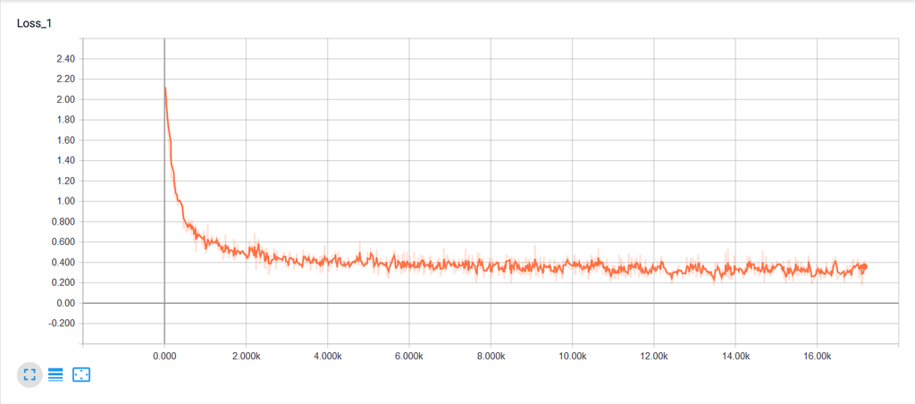

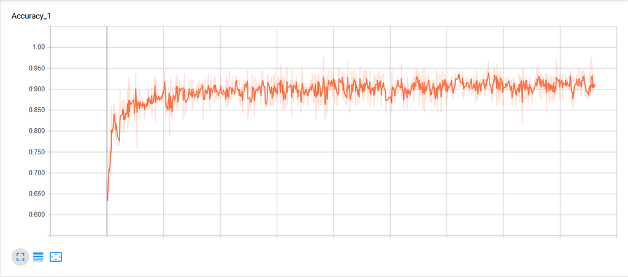

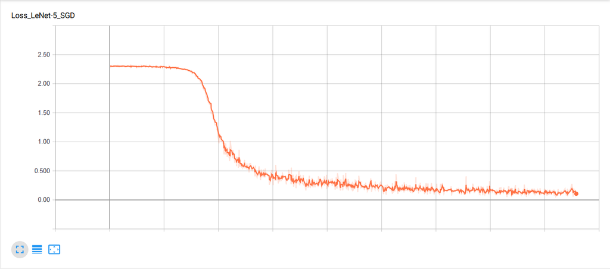

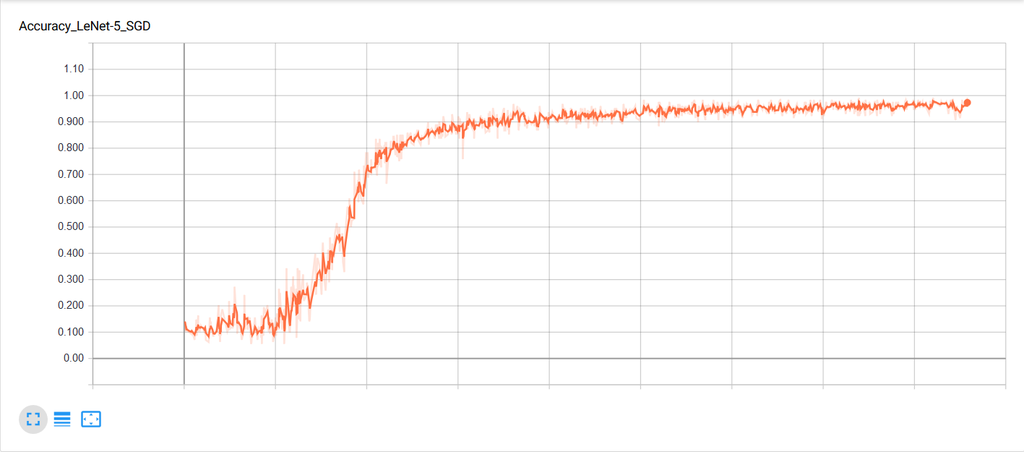

We divided the error by more than two, this is a huge improvment. The number of iterations seems good, as both accuracy and loss curves are flattening at the end of the training. We can notice that for LeNet optimization, the loss function is slow to decrease, but become very low when it starts to do so.

**Part 2** : LeNET 5 Optimization

**Question 2.2.1**

- Retrain your network with AdamOptimizer and then fill the table above:

| Optimizer | Gradient Descent | AdamOptimizer |
| --- | --- | --- |
| Testing Accuracy | 0.966 | 0.983 |
| Training Time | 10min 01s | 10min 03s |

- Which optimizer gives the best accuracy on test data?

For instance, Adam is set to:

```
learning_rate=0.001,
    beta1=0.9,
    beta2=0.999,
    epsilon=1e-08,
    use_locking=False,
    name='Adam'
```

```python
tf.reset_default_graph()

# Model
x = tf.placeholder(tf.float32, shape=(None, 784), name='InputData')
y = tf.placeholder(tf.float32, shape=(None, 10), name='LabelData')

modelADAM = LeNet5_Model(x)

with tf.name_scope('Accuracy_ADAM'):
    accuracyADAM = evaluate(modelADAM, y)
with tf.name_scope('Loss_ADAM'):
    costADAM = tf.reduce_mean(-tf.reduce_sum(y*tf.log(tf.clip_by_value(modelADAM, epsilon, 1.0)), reduction_indices=1))
with tf.name_scope('Optimisation_ADAM'):
    optimizerADAM = tf.train.AdamOptimizer(learning_rate).minimize(costADAM)

# Initializing the variables
init = tf.global_variables_initializer()
# Create a summary to monitor cost tensor
tf.summary.scalar("Loss_LeNet-5_Adam", costADAM)
# Create a summary to monitor accuracy tensor
tf.summary.scalar("Accuracy_LeNet-5_Adam", accuracyADAM)
# Merge all summaries into a single op
merged_summary_op = tf.summary.merge_all()
```

```python
%%time
with tf.Session() as sess:
    train(init, sess, logs_path, training_epochs, batch_size, optimizerADAM, costADAM, accuracyADAM, merged_summary_op)
print("Elapsed time:")
```

```
Epoch 10	- Training data loss = 0.000235501
		- Test data accuracy = 0.982
Epoch 20	- Training data loss = 0.000209198
		- Test data accuracy = 0.986
Epoch 30	- Training data loss = 0.000043319
		- Test data accuracy = 0.985
Epoch 40	- Training data loss = 0.000290127
		- Test data accuracy = 0.983
Final Accuracy=0.983
Elapsed time:
CPU times: user 56min 20s, sys: 14min 46s, total: 1h 11min 7s
Wall time: 10min 3s
```

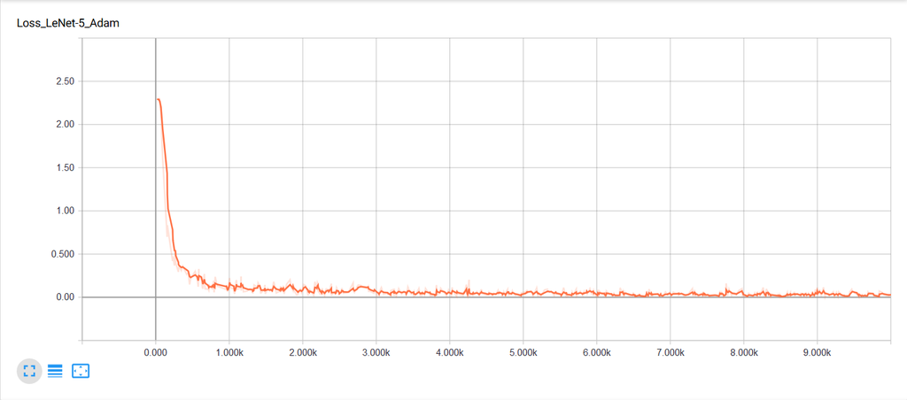

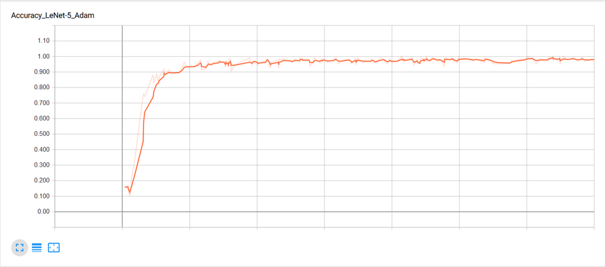

**Question 2.2.2** Try to add dropout (keep_prob = 0.75) before the first fully connected layer. You will use tf.nn.dropout for that purpose. What accuracy do you achieve on testing data?

```python
def LeNet5_Model_Dropout(*args, **kwargs):
    return LeNet5_Model(*args, **kwargs, dropout=True)
```

```python
tf.reset_default_graph()

# Model
x = tf.placeholder(tf.float32, shape=(None, 784), name='InputData')
y = tf.placeholder(tf.float32, shape=(None, 10), name='LabelData')

modelDrop = LeNet5_Model_Dropout(x)

with tf.name_scope('Accuracy_DROPOUT'):
    accuracyDROP = evaluate(modelDrop, y)
with tf.name_scope('Loss_DROPOUT'):
    costDROP = tf.reduce_mean(-tf.reduce_sum(y*tf.log(tf.clip_by_value(modelDrop, epsilon, 1.0)), reduction_indices=1))
with tf.name_scope('Optimisation_DROPOUT'):
    optimizerDROP = tf.train.AdamOptimizer(learning_rate).minimize(costDROP)

# Initializing the variables
init = tf.global_variables_initializer()
# Create a summary to monitor cost tensor
tf.summary.scalar("Loss_LeNet-5_Drop", costDROP)
# Create a summary to monitor accuracy tensor
tf.summary.scalar("Accuracy_LeNet-5_Drop", accuracyDROP)
# Merge all summaries into a single op
merged_summary_op = tf.summary.merge_all()
```

```python
%%time
with tf.Session() as sess:
    train(init, sess, logs_path, training_epochs, batch_size, optimizerDROP, costDROP, accuracyDROP, merged_summary_op)
print("Elapsed time:")
```

```
Epoch 10	- Training data loss = 0.000125411
		- Test data accuracy = 0.978
Epoch 20	- Training data loss = 0.000041697
		- Test data accuracy = 0.982
Epoch 30	- Training data loss = 0.000018722
		- Test data accuracy = 0.985
Epoch 40	- Training data loss = 0.000032723
		- Test data accuracy = 0.984
Final Accuracy=0.986
Elapsed time:
CPU times: user 57min 4s, sys: 12min 9s, total: 1h 9min 14s
Wall time: 10min 14s
```

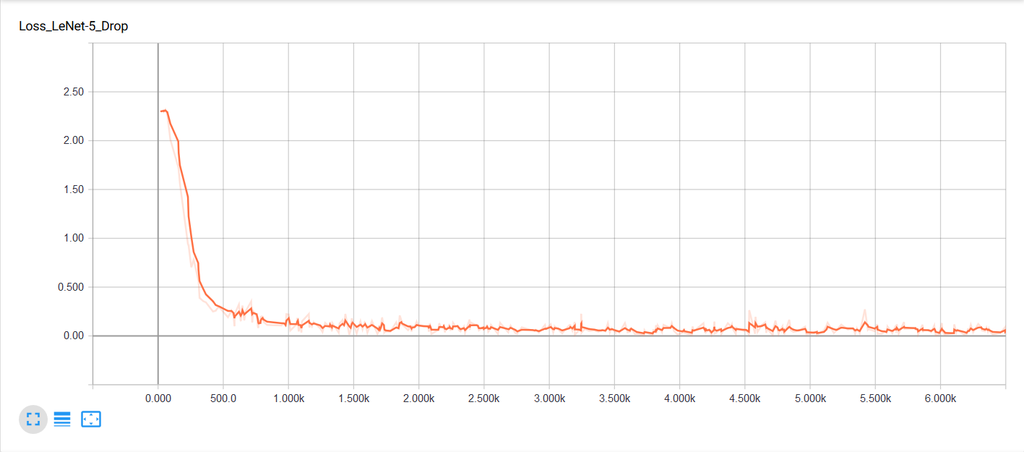

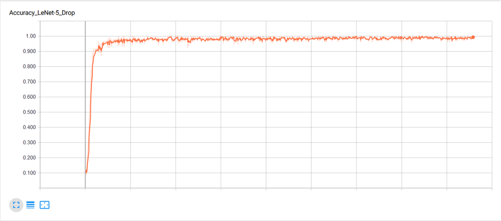